# IMA Day 4 Notes

## Getting Started

**Load packages required for exercises:**

```r
suppressPackageStartupMessages(library(dplyr))
suppressPackageStartupMessages(library(ggplot2))
```

## Motivating Example

```r
mydata <- data.frame(x = c(1:5))
mydata
```

```
##   x
## 1 1
## 2 2
## 3 3
## 4 4
## 5 5
```

```r
sample_n(mydata, size=3)
```

```
##   x
## 1 1
## 3 3
## 5 5
```

```r
sample_n(mydata, size=3, replace=TRUE)
```

```
##     x
## 4   4
## 4.1 4
## 1   1
```

### Exercise 1

```r
#Step 1: set up a 2 card deck
deck <- data.frame(card=c("fire", "no fire"))
deck
```

```
##      card
## 1    fire
## 2 no fire
```

```r
#Step 2: Randomly pick a card from the deck 17 times
suppressPackageStartupMessages(library(dplyr))
outcome <- sample_n(deck, size = 17, replace=TRUE)

#Step 3: Check out the results
table(outcome)
```

```
## outcome
##    fire no fire
##       8       9
```

### Exercise 2

part a:

```r
#set the seed
set.seed(2000)
#initialize the for loop
Trials <- data.frame(fire = rep(0,500), nofire = rep(0,500))
#run the for loop
for(i in 1:500){
    #randomly pick a card from the deck 17 times
    outcome <- sample_n(deck, size = 17, replace=TRUE)

    #store the results in Trials
    Trials[i,] <- table(outcome)
}

#check out the first 6 experiment results
head(Trials)
```

```
##   fire nofire
## 1    9      8
## 2    6     11
## 3    9      8
## 4    9      8
## 5   10      7
## 6    6     11
```

part b:

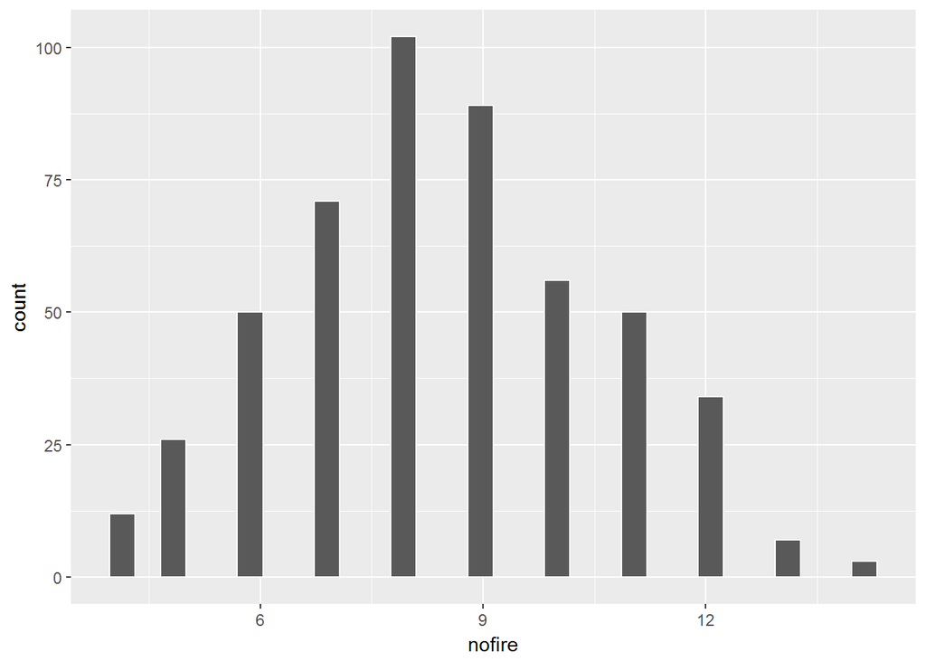

```r
ggplot(Trials, aes(x=nofire)) +
    geom_histogram(color="white")
```

part c:

```r
min(Trials$nofire)
```

```
## [1] 4
```

```r
max(Trials$nofire)
```

```
## [1] 14
```

```r
table(Trials$nofire)
```

```
##
##   4   5   6   7   8   9  10  11  12  13  14
##  12  26  50  71 102  89  56  50  34   7   3
```

### Exercise 3

1. No. 14/17 is not a typical result
2. 3/500 = 0.006
3. Null hypothesis is false. We conclude that P.S has blindsight.

### Exercise 4

What if, instead, P.S. had chosen the non-burning house 10 out of 17 times.

## Hypothesis Testing for Model Coefficients

```r
ps <- read.csv("https://www.macalester.edu/~ajohns24/data/PetStress.csv")
head(ps, 3)
```

```
##   Condition MaxHeartRate MeanHeartRate Height Age YearUnion
## 1         P           72         69.17     65  47      1837
## 2         P           72         68.86     62  49      1959
## 3         C          115         84.74     63  29      1890
```

### Exercise 5

2. On average, heart rate increases with age.
3. Symmetric Bell shaped distribution with mean zero.

### Exercise 6

part a:

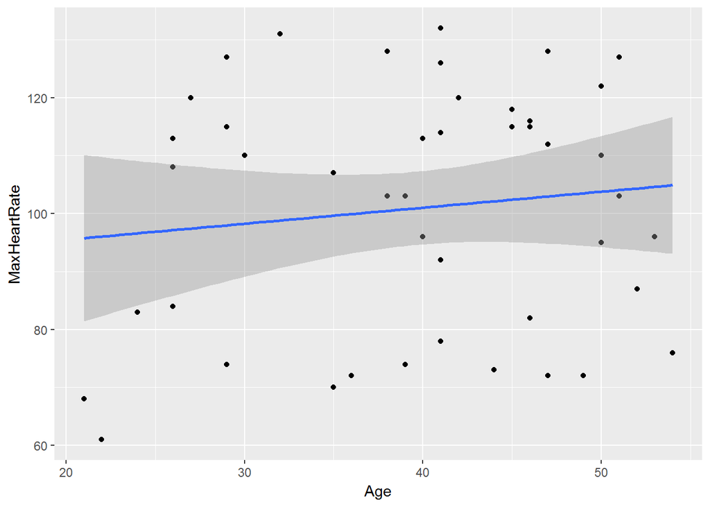

```r
#plot
ggplot(ps, aes(x=Age,y=MaxHeartRate)) +
      geom_point() +
      geom_smooth(method="lm")
```

```r
#model
HeartMod1 <- lm(MaxHeartRate ~ Age, data=ps)
summary(HeartMod1)
```

```
##
## Call:
## lm(formula = MaxHeartRate ~ Age, data = ps)
##
## Residuals:
##     Min      1Q  Median      3Q     Max
## -35.051 -20.687   6.207  15.843  32.184
##
## Coefficients:
##             Estimate Std. Error t value Pr(>|t|)
## (Intercept)  89.9672    13.9396   6.454 7.98e-08 ***
## Age           0.2765     0.3432   0.806    0.425
## ---
## Signif. codes:  0 '***' 0.001 '**' 0.01 '*' 0.05 '.' 0.1 ' ' 1
##
## Residual standard error: 21.03 on 43 degrees of freedom
## Multiple R-squared:  0.01487,    Adjusted R-squared:  -0.008037
## F-statistic: 0.6492 on 1 and 43 DF,  p-value: 0.4248
```

```r
confint(HeartMod1, level=0.95)
```

```
##                  2.5 %      97.5 %
## (Intercept) 61.8554100 118.0790414
## Age         -0.4155818   0.9686136
```

2. We don’t have enough evidence to “reject” $H_{0}$ as 0 lies in the CI.
3. 0.3432 t-value:how many standard errors away from 0 is $\hat{\beta_{1}}$

```r
0.2765/0.3432
```

```
## [1] 0.8056527
```

It is relatively close to 0 by 68-95-99.7 rule

### Exercise 7

1. > 0.05

```r
#Probability that it is more than 0.8* sd away from 0. (two sided)
1- 0.8*0.68
```

```
## [1] 0.456
```

```r
#one-sided
(1- 0.8*0.68)/2
```

```
## [1] 0.228
```

3. It’s not unlikely that we’d have observed such a strong increase in heart rate with age if in fact there were no relationship between these variables in the broader population.
4. Don’t reject $H_{0}$ . We don’t have enough evidence to conclude that, on average, heart rate increases with age

### Exercise 8

a

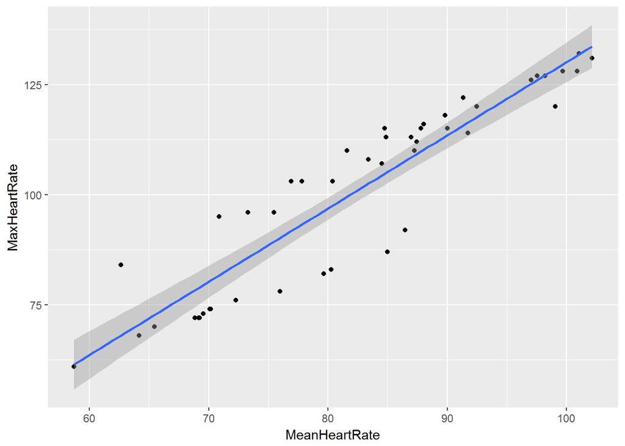

```r
#plot
ggplot(ps, aes(y=MaxHeartRate,x=MeanHeartRate)) +
      geom_point() +
      geom_smooth(method="lm")
```

```r
#model
HeartMod2 <- lm(MaxHeartRate ~ MeanHeartRate, data=ps)
summary(HeartMod2)
```

```
##
## Call:
## lm(formula = MaxHeartRate ~ MeanHeartRate, data = ps)
##
## Residuals:
##      Min       1Q   Median       3Q      Max
## -18.1563  -6.3695   0.8248   5.5356  15.9740
##
## Coefficients:
##               Estimate Std. Error t value Pr(>|t|)
## (Intercept)   -36.0554     8.8412  -4.078 0.000193 ***
## MeanHeartRate   1.6613     0.1062  15.642  < 2e-16 ***
## ---
## Signif. codes:  0 '***' 0.001 '**' 0.01 '*' 0.05 '.' 0.1 ' ' 1
##
## Residual standard error: 8.192 on 43 degrees of freedom
## Multiple R-squared:  0.8505, Adjusted R-squared:  0.847
## F-statistic: 244.7 on 1 and 43 DF,  p-value: < 2.2e-16
```

```r
confint(HeartMod2, level=0.95)
```

```
##                    2.5 %     97.5 %
## (Intercept)   -53.885338 -18.225428
## MeanHeartRate   1.447121   1.875507
```

$\hat{\beta_{1}}$ : Estimate = 1.6613, SE= 0.1062

3. The esitmate is t-value (15.642) times SE away from 0. This means if the null hypothesis were true, this would be quite unlikely (w.r.t the significance level $\alpha = 0.05$).
4. p-value

```r
#one-sided
(1- 15.642*0.68)/2
```

```
## [1] -4.81828
```

The probability that this data is not as extreme if our null hypothesis is true is p-value < 2.2e-16

5. Thus, we reject the null hypothesis that there is no co-relation between person’s maximum heart rate to their mean heart rate.

### Exercise 9

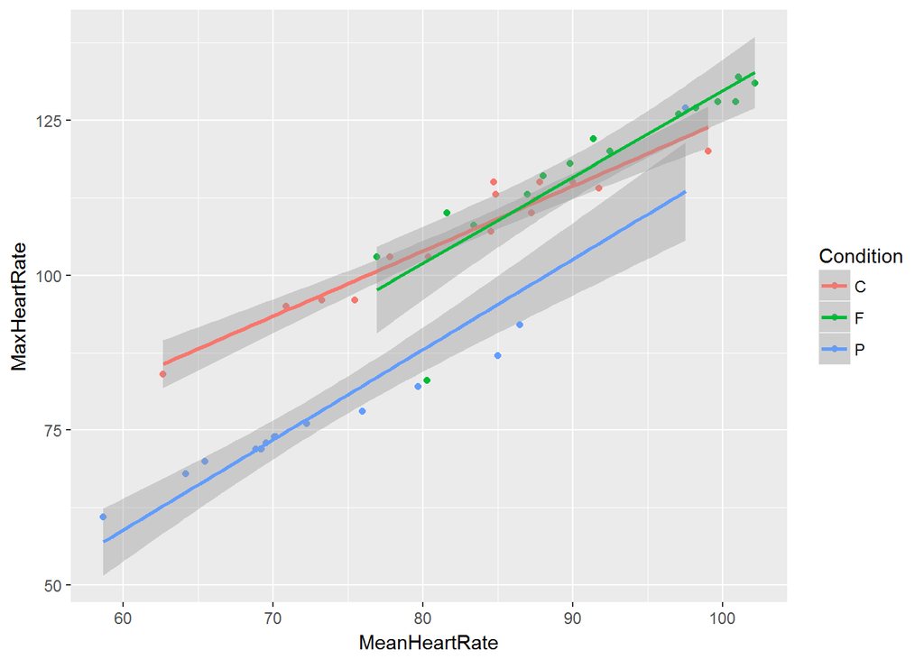

```r
#plot
ggplot(ps, aes(y=MaxHeartRate,x=MeanHeartRate, color = Condition)) +
      geom_point() +
      geom_smooth(method="lm")
```

```r
#model
HeartMod3 <- lm(MaxHeartRate ~ MeanHeartRate + Condition , data=ps)
summary(HeartMod3)
```

```
##
## Call:
## lm(formula = MaxHeartRate ~ MeanHeartRate + Condition, data = ps)
##
## Residuals:
##      Min       1Q   Median       3Q      Max
## -20.2876  -1.2901  -0.1028   1.9246  17.1492
##
## Coefficients:
##                Estimate Std. Error t value Pr(>|t|)
## (Intercept)    -0.89994    7.19300  -0.125    0.901
## MeanHeartRate   1.30182    0.08568  15.194  < 2e-16 ***
## ConditionF     -0.32270    2.01348  -0.160    0.873
## ConditionP    -16.22893    2.02133  -8.029 6.06e-10 ***
## ---
## Signif. codes:  0 '***' 0.001 '**' 0.01 '*' 0.05 '.' 0.1 ' ' 1
##
## Residual standard error: 5.113 on 41 degrees of freedom
## Multiple R-squared:  0.9445, Adjusted R-squared:  0.9404
## F-statistic: 232.5 on 3 and 41 DF,  p-value: < 2.2e-16
```

```r
confint(HeartMod3, level=0.95)
```

```
##                    2.5 %     97.5 %
## (Intercept)   -15.426495  13.626611
## MeanHeartRate   1.128786   1.474857
## ConditionF     -4.388996   3.743599
## ConditionP    -20.311091 -12.146764
```

2. $\hat{\beta_{0}}$: MaxHeartBeat of a person when their MeanHeartRate = 0 and subject is in controlled environment. $\hat{\beta_{1}}$: Change in MaxHeartBeat when MeanHeartBeat change by $\hat{\beta_{1}}$ in controlled environment.

$\hat{\beta_{2}}$ The amount by which MaxHeartBeat differs from when they are in controlled environment of a person when their MeanHeartRate = 0 and they are with a friend

$\hat{\beta_{3}}$ The amount by which MaxHeartBeat differs from when they are in controlled environment of a person when their MeanHeartRate = 0 and they are with a pet

3. While Controlling for the Condition parameter, is MeanHeartRate and MAxHeartRate associated with each other significantly

p-value < 2e-16

Controlling for the Condition Paramter, we have significant evidence to reject the null hypothesis i.e we reject the hypothesis that there is no co-relation between MeanHeartRate and MaxHeartRate.

d.ConditionF Null hypothesis would state there is difference in MaxHeartRate for same MeanHeartRate as you change environment from controlled to Friend present.

The estimate is t-value (-0.160) times SE away from 0 when meanheartrate is same as you change environment from controlled to Friend present.

p-value = 0.873/2 - Probability that assuming $H_{0}$.

Not enough evidence to reject the null hypothesis

5. Reject Null Hypothesis

### Exercise 10

```r
interactionMod <- lm(MaxHeartRate ~ MeanHeartRate*Condition, ps)
summary(interactionMod)
```

```
##
## Call:
## lm(formula = MaxHeartRate ~ MeanHeartRate * Condition, data = ps)
##
## Residuals:
##      Min       1Q   Median       3Q      Max
## -19.3040  -1.6282   0.2896   2.4271  13.4496
##
## Coefficients:
##                          Estimate Std. Error t value Pr(>|t|)
## (Intercept)               19.8604    11.8831   1.671   0.1027
## MeanHeartRate              1.0503     0.1432   7.336 7.43e-09 ***
## ConditionF               -29.2157    18.7796  -1.556   0.1279
## ConditionP               -48.2899    15.4242  -3.131   0.0033 **
## MeanHeartRate:ConditionF   0.3406     0.2137   1.594   0.1190
## MeanHeartRate:ConditionP   0.4053     0.1952   2.077   0.0445 *
## ---
## Signif. codes:  0 '***' 0.001 '**' 0.01 '*' 0.05 '.' 0.1 ' ' 1
##
## Residual standard error: 4.95 on 39 degrees of freedom
## Multiple R-squared:  0.9505, Adjusted R-squared:  0.9442
## F-statistic: 149.8 on 5 and 39 DF,  p-value: < 2.2e-16
```

```r
confint(interactionMod, level=0.95)
```

```
##                                 2.5 %      97.5 %
## (Intercept)               -4.17546886  43.8963392
## MeanHeartRate              0.76069262   1.3398235
## ConditionF               -67.20094011   8.7695698
## ConditionP               -79.48840546 -17.0914763
## MeanHeartRate:ConditionF  -0.09156422   0.7727935
## MeanHeartRate:ConditionP   0.01053714   0.8001603
```

MeanHeartRate:ConditionF - Not significant - Don’t reject Null Hypothesis MeanHeartRate:Conditionp - Significant - Reject Null Hypothesis

## Potential Errors in Hypothesis Testing

### Exercise 11

```r
dd <- c(0.01, 0.03, 0.59, 0.02, 0.55, 0.09, 1.36, 0.61, 0.18, 0.06)
mean(dd)
```

```
## [1] 0.35
```

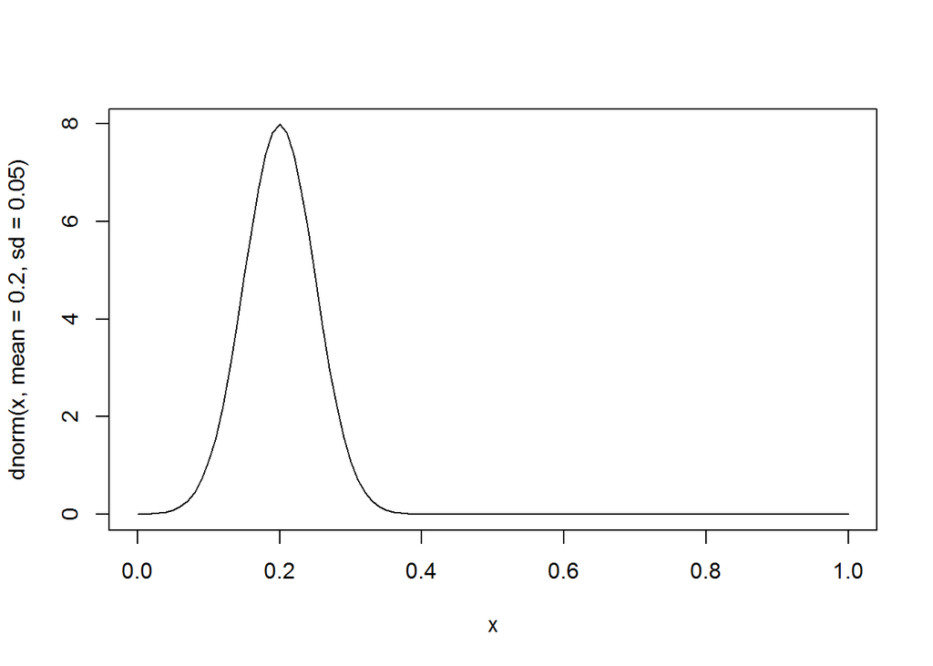

```r
curve(dnorm(x, mean=0.2, sd=0.05))
```

```r
pnorm(0.35, mean=0.2, sd=0.05, lower=FALSE)
```

```
## [1] 0.001349898
```

3. Reject $H_{0}$ . We have statistically significant evidence that the driver is not sober.

### Exercise 12

1. Type 1 error: Conclude that a sober driver is drunk.
2. Type II Error: Drunk driver is sober

### Exercise 13

```r
qnorm(0.95, mean=0.2, sd=0.05)
```

```
## [1] 0.2822427
```

```r
sober <- rnorm(1000, mean=0.2, sd=0.05)
sum(sober> 0.2822)/10
```

```
## [1] 5.1
```

### Exercise 14

```r
BAC8 <- rnorm(1000, mean=(0.2+ 4*0.08), sd=(0.05+0.08)**2)
```

```r
sum(BAC8 < 0.2822)/10
```

```
## [1] 0
```

```r
BAC15 <- rnorm(1000, mean=(0.2+ 4*0.15), sd=(0.05+0.15)**2)
```

```r
sum(BAC15 <= 0.2822)/10
```

```
## [1] 0
```

### Exercise 15